# Capital Asset Pricing Model

- Work on problems of different distributions eg., gaussian
- Calculate z score
- Make statistical inferences on given data
- Construct a null and an alternate hypothesis
- Find the p-value for a given hypothesis and T test statistic.

```python
from math import sqrt
%matplotlib inline

import numpy as np
import pandas as pd
import scipy.stats as stats
import matplotlib.pyplot as plt
import math
```

The Capital Asset Pricing Model (CAPM) is a financial model that assumes returns on a portfolio are normally distributed. Suppose a portfolio has an average annual return of 14.7% (i.e., an average gain on 14.7%) with a standard deviation of 33%. A return of 0% means the value of the portfolio doesn't change, a negative return means that the portfolio loses money, and a positive return means that the portfolio gains money. Determine the following:

1. What percentage of years does this portfolio lose money, (i.e. have a return less than 0%)?
2. What is the cutoff for the highest 15% of annual returns with this portfolio?

See CAPM here https://en.wikipedia.org/wiki/Capital_asset_pricing_model

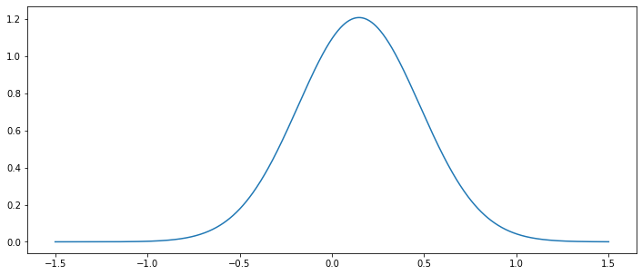

```python
#A)

mean = 0.147
se = 0.33
plt.figure(figsize=(12,5))

x1=np.linspace(-1.5,1.5,1000)
y1= stats.norm.pdf(x1,loc=mean, scale = se)
plt.plot(x1,y1)
```

```python
cdf = stats.norm.cdf(0, loc=mean, scale = se)
print(f"Based on our calculation the probability of yearly returns being 0% or less are {cdf.round(2)*100}%")
```

```
Based on our calculation the probability of yearly returns being 0% or less are 33.0%
```

```python
#B)
ppf = stats.norm.ppf(0.85, loc=mean, scale = se)
print(f"Based on our calculation the cutoff of the highest 15% returns possible in the portfolio is {ppf.round(2)*100}%")
```

```
Based on our calculation the cutoff of the highest 15% returns possible in the portfolio is 49.0%
```

Past experience indicates that because of low morale, a company loses 20 hours a year per employee due to lateness and abstenteeism. Assume that the standard deviation of the population is 6 and normally distributed.

The HR department implemented a new rewards system to increase employee morale, and after a few months it collected a random sample of 20 employees and the annualized absenteeism was 14.

1. Could you confirm that the new rewards system was effective with a 90% confidence?
2. An HR subject matter expert would be very happy if the program could reduce absenteeism by 20% (i.e. to 16 hours). Given the current sampling parameters (sample size of 20 and std. dev. of population. 6), what is t the probability that the new rewards system reduced absenteeism to 16 hours and you miss it?
3. What should the sample size be if you want β to be 5%

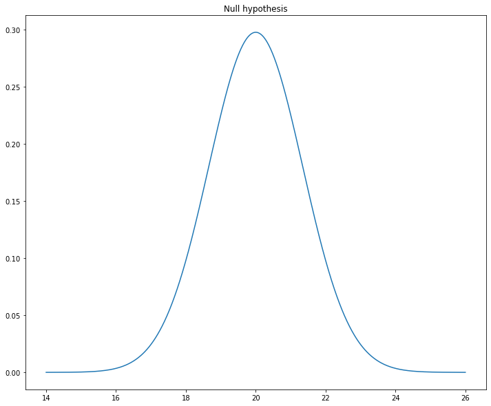

```python
n_samples = 20
sigma = 6

se = sigma/sqrt(n_samples)

plt.figure(figsize=(12,10))

x = np.linspace(14, 26, 1000)
plt.plot(x, stats.norm.pdf(x, loc=20, scale=se))

plt.title("Null hypothesis")
```

```python
p_value= stats.norm.cdf(14, loc=20, scale=se)
print('P-value for given sample is ', p_value)
```

```
P-value for given sample is  3.872108215522035e-06
```

Because P-value is a lot smaller than the 0.1 degrees of significance we in fact can confirm that the new rewards system have benefited the employee attendance with 90% confidence. However because the sample is so small there will always be a chance of sampling error.

```python
#B)
ppf = stats.norm.ppf(0.9, loc=14, scale = se)
power_of_test = 1-stats.norm.cdf(ppf,loc = 16, scale= se)
print(f"The probability of the hours of absenteeism being 16 hours and us missing the acceptable result are {power_of_test.round(3)*100}%.")
```

```
The probability of the hours of absenteeism being 16 hours and us missing the acceptable result are 58.3%.
```

```python
#C)
mean = 14
sigma = 6
mean_new = 16
for i in range(1,100000):
    se = sigma/np.sqrt(i)
    ppf = stats.norm.ppf(0.9, loc=mean, scale=se)
    beta = (stats.norm.cdf(ppf, loc=mean_new, scale=se))
    if beta<0.05:
        break
print(f"For us to have a beta of 5 we will need to have a sample of {i} people.")
```

```
For us to have a beta of 5 we will need to have a sample of 78 people.
```

```python
from scipy.stats import chi2, chi2_contingency, chisquare
```

Chi-Square Goodness of fit

```python
expected = []
over_seven = 0
for i in range(1,8):
    if i >= 7:
        for i in range(7,1000):
            over_seven += round((1362*((1-0.545)**(i-1)*0.545)),0)
    else:
        expect = round((1362*((1-0.545)**(i-1)*0.545)),0)
        expected.append(expect)
expected.append(over_seven)
```

```python
expected
```

```
[742.0, 338.0, 154.0, 70.0, 32.0, 14.0, 12.0]
```

```python
chisquare(expected,[717,369,155,69,28,14,10])
```

```
Power_divergenceResult(statistic=4.468396568484178, pvalue=0.6135586684163903)
```

What we have received in the expected list is the geometric distribution of our expected days without market reversing to a positive return. If taken at face value I would consider the Expected and Observed data sets to have a very close correlation, especially 3 days and onwards. However by our chi-square test we find that the P-value of this distribution shows us a 61% significance level. This is a massive sign that the Null Hypothesis cannot be rejected since our significance level is so much higher than 5%. With significance this high it follows that the market is in fact a random walk with no "promised due dates". What this means for market participants is that gambling on buying stocks low when they really feel like an up day is "due" is no more than a gamble and the market will be down for as long as it wants.